# Sample Analysis

# Combined Results

```r
rm(list=ls())
load("loaded_data/one.RData")
load("loaded_data/two.RData")
load("loaded_data/three.RData")
load("loaded_data/four.RData")
load("loaded_data/five.RData")
load("loaded_data/combined.RData")









#
#
# df_0 <- cbind.data.frame(college$condition,college$InCS,college$cog_number_right,college$NFC,college$reason_always,college$changed,college$gender, college$Ju1_bin, college$Ju2_bin,college$right_change)
# colnames(df_0) <- c("condition","InCS","cog_load_CS_num","NFC","reason_always","changed","gender","Ju1_bin","Ju2_bin","right_change")
#
#
# df1 <- cbind.data.frame(one$condition,one$InCS,one$cog_load_CS_num,one$NFC,one$reason_always,one$changed,one$gender, one$Ju1_bin, one$Ju2_bin,one$right_change)
# colnames(df1) <- c("condition","InCS","cog_load_CS_num","NFC","reason_always","changed","gender","Ju1_bin","Ju2_bin","right_change")
# df2 <- cbind.data.frame(two$condition,two$InCS,two$cog_load_CS_num,two$NFC,two$reason_always,two$changed,two$gender, two$Ju1_bin, two$Ju2_bin,two$right_change)
# colnames(df2) <- c("condition","InCS","cog_load_CS_num","NFC","reason_always","changed","gender","Ju1_bin","Ju2_bin","right_change")
#
# df3 <- three
# df3 <- df3[which(df3$engaged==T),]
# three <- df3
#
#
# df3 <- cbind.data.frame(three$condition,three$InCS,three$cog_load_CS_num,three$NFC,three$reason_always,three$changed,three$gender, three$Ju1_bin, three$Ju2_bin,three$right_change)
# colnames(df3) <- c("condition","InCS","cog_load_CS_num","NFC","reason_always","changed","gender","Ju1_bin","Ju2_bin","right_change")
#
# df5 <- cbind.data.frame(study5$condition,study5$InCS,study5$cog_number_right,study5$NFC,study5$reason_always,study5$changed,study5$gender, study5$Ju1_bin, study5$Ju2_bin,study5$right_change)
# colnames(df5) <- c("condition","InCS","cog_load_CS_num","NFC","reason_always","changed","gender","Ju1_bin","Ju2_bin","right_change")
#
# two_three <- rbind.data.frame(df2,df3)
# one_two_three <- rbind.data.frame(df1,df2,df3)
# zero_one_two_three <- rbind.data.frame(df_0, df1,df2,df3)
# zero_one_two_three_five <- rbind.data.frame(df_0, df1,df2,df3,df5)
#
# zero_two_three <- rbind.data.frame(df_0,df2,df3)
#
# three_five <- rbind.data.frame(df3, df5)
#
# table(three_five$InCS,three_five$condition)
# chisq.test(table(three_five$InCS,three_five$condition))
#
#
# one_two_three$changed <- car::recode(one_two_three$changed,"'TRUE'='changed';'FALSE'='not_changed'" )
# one_two_three$reason_always <- car::recode(one_two_three$reason_always,"'TRUE'='reason';'FALSE'='not_always_reason'" )
#
#
# zero_one_two_three$changed <- car::recode(zero_one_two_three$changed,"'TRUE'='changed';'FALSE'='not_changed'" )
# zero_one_two_three$reason_always <- car::recode(zero_one_two_three$reason_always,"'TRUE'='reason';'FALSE'='not_always_reason'" )
#
# #no_right <- zero_one_two_three[which(zero_one_two_three$right_change!="right initially"|zero_one_two_three$InCS!="There is nothing wrong."),]
#
# zero_one_two_three$right_right <- zero_one_two_three$InCS=="There is nothing wrong."&zero_one_two_three$right_change=="right initially"
#
# #df3$right_right <- df3$InCS=="There is nothing wrong."&df3$right_change=="right initially"
#
# no_right <- zero_one_two_three[which(zero_one_two_three$right_right==FALSE),]
#
# zero_one_two_three$InCS=="There is nothing wrong."
# zero_one_two_three$right_change=="right initially"
#
# tapply(zero_one_two_three$NFC,zero_one_two_three$right_change, descriptives)
# summary(aov(NFC~right_change,zero_one_two_three))
# TukeyHSD(aov(NFC~right_change,zero_one_two_three))
#
# tapply(zero_one_two_three$NFC,zero_one_two_three$InCS, descriptives)
# summary(aov(NFC~InCS,zero_one_two_three))
# TukeyHSD(aov(NFC~InCS,zero_one_two_three))
#
#
# tapply(no_right$NFC,no_right$InCS, descriptives)
# summary(aov(NFC~InCS,no_right))
# TukeyHSD(aov(NFC~InCS,no_right))
#
#
#
# tapply(zero_one_two_three_five$NFC,zero_one_two_three_five$InCS, descriptives)
# summary(aov(NFC~InCS, data=zero_one_two_three_five))
# TukeyHSD(aov(NFC~InCS,zero_one_two_three_five))
#
#
# #
# # tapply(engaged0_2_3$NFC,engaged0_2_3$right_change, descriptives)
# # summary(aov(NFC~right_change,engaged0_2_3))
# # TukeyHSD(aov(NFC~right_change,engaged0_2_3))
# #
# # #
# # tapply(engaged0_2_3$NFC,engaged0_2_3$InCS, descriptives)
# # summary(aov(NFC~InCS,engaged0_2_3))
# # TukeyHSD(aov(NFC~InCS,engaged0_2_3))
#
# tapply(no_right$NFC,no_right$right_change, descriptives)
# summary(aov(NFC~right_change,no_right))
# TukeyHSD(aov(NFC~right_change,no_right))
#
#
# tapply(no_right$NFC,no_right$InCS, descriptives)
# summary(aov(NFC~InCS,no_right))
# TukeyHSD(aov(NFC~InCS,no_right))
#
#
# table(two_three$condition)
# table(two_three$condition,two_three$InCS)
# chisq.test(table(two_three$condition,two_three$InCS))
# engaged2_3 <- two_three[which(two_three$cog_load_CS_num>6|two_three$condition=="control"),]
# table(engaged2_3$condition,engaged2_3$InCS)
# chisq.test(table(engaged2_3$condition,engaged2_3$InCS))
# table(engaged2_3$condition)
#
# engaged2_3 <- two_three[which(two_three$cog_load_CS_num>7|two_three$condition=="control"),]
# engaged0_2_3 <- rbind.data.frame(engaged2_3,df_0)
#
# table(engaged2_3$condition,engaged2_3$InCS)
# chisq.test(table(engaged2_3$condition,engaged2_3$InCS))
# table(engaged2_3$condition)
#
# table(engaged0_2_3$condition,engaged0_2_3$InCS)
# chisq.test(table(engaged0_2_3$condition,engaged0_2_3$InCS))
# table(engaged0_2_3$condition)
#
# engaged2_3a <- two_three[which(two_three$cog_load_CS_num>6|two_three$condition=="control"),]
# engaged2_3b <- two_three[which(two_three$cog_load_CS_num>7|two_three$condition=="control"),]
# engaged0_2_3a <- rbind.data.frame(engaged2_3a,df_0)
# engaged0_2_3b <- rbind.data.frame(engaged2_3b,df_0)
# one_e <- cbind.data.frame(one$engaged, one$InCS, one$cog_load_CS_num, one$NFC, one$reason_always, one$changed,one$gender, one$Ju1_bin, one$Ju2_bin,one$right_change)
# colnames(one_e) <- c("condition","InCS","cog_load_CS_num","NFC","reason_always","changed","gender","Ju1_bin","Ju2_bin","right_change")
# one_e$condition <- car::recode(one_e$condition, "'engaged'='cog_load';'not engaged'='control'")
# eng_0123a <- rbind(engaged0_2_3a,one_e, df5)
# eng_0123b <- rbind(engaged0_2_3b,one_e, df5)
#
#
# table(eng_0123a$InCS,eng_0123a$condition)
# chisq.test(table(eng_0123a$InCS,eng_0123a$condition))
#
# table(eng_0123b$InCS,eng_0123b$condition)
# chisq.test(table(eng_0123b$InCS,eng_0123b$condition))
```

```r
rbind(table(engaged0_2_3a$InCS,engaged0_2_3a$condition),
      table(engaged0_2_3b$InCS,engaged0_2_3b$condition))
```

```
##                                              cog_load control
## There is nothing wrong.                            49      32
## It's wrong but I can't think of a reason.          33      22
## It's wrong and I can provide a valid reason.       83     103
## There is nothing wrong.                            49      32
## It's wrong but I can't think of a reason.          32      22
## It's wrong and I can provide a valid reason.       75     103
```

```r
make4table1 <- function(){

  tb_count_perc <- function(x){
  tc <- table(x$InCS,x$condition)
  cbind(tc[,1],paste0(round(tc[,1]/sum(x$condition=="cog_load")*100),"%"),
        tc[,2],paste0(round(tc[,2]/sum(x$condition=="control")*100),"%"))
}


  rows <- c("Nothing wrong","Dumbfounded","Reasons")

  t0 <- tb_count_perc(college)
  t1 <- tb_count_perc(one)
  t2 <- tb_count_perc(two)
  t3 <- tb_count_perc(three)
  t5 <- tb_count_perc(study5)
  t23 <- tb_count_perc(two_three)
  t23e7 <- tb_count_perc(engaged0_2_3a)
  t23e8 <- tb_count_perc(engaged0_2_3b)
  t023 <- tb_count_perc(zero_two_three)
  t0123 <- tb_count_perc(zero_one_two_three)
  t01235 <- tb_count_perc(zero_one_two_three_five)


  c("Study 1"," "," ",
                 "Study 2"," "," ",
                 "Study 3"," "," ",
                 "Study 4"," "," ",
    "Study 5"," "," ",
                 "Studies 3 and 4"," "," ",
                 "Studies 3 and 4 engaged 1"," "," ",
                 "Studies 3 and 4 engaged 2"," "," ",
                 "Studies 1, 3, and 4"," "," ",
                 "Studies 1, 2, 3, and 4"," "," ")
  rbind(t0,t1,t2,t3,t5,t23,t23e7,t23e8,t023,t01235)

  rows_left <- c("Study 1"," "," ",
                 "Study 2"," "," ",
                 "Study 3"," "," ",
                 "Study 4"," "," ",
                 "Study 5"," "," ",
                 "Studies 3 and 4"," "," ",
                 "Studies 3 and 4 engaged 1"," "," ",
                 "Studies 3 and 4 engaged 2"," "," ",
                 "Studies 1, 3, and 4"," "," ",
                 "Studies 1, 2, 3, and 4"," "," ")


  test1 <- cbind(c("Study 1*"," "," ",
                       "Study 2"," "," ",
                       "Study 3*"," "," ",
                       "Study 4"," "," ",
                   "Study 5"," "," ",
                       "All Studies*"," "," "),
                     rows,
                     unname(rbind(t0,t1,t2,t3,t5,t01235)))

  cols <- c("Study","Response","N","percent","N","percent")
  test1 <- `colnames<-`(test1, cols)

  test1

}

make4table1()
```

```
##       Study          Response        N     percent N     percent
##  [1,] "Study 1*"     "Nothing wrong" "15"  "45%"   "5"   "15%"
##  [2,] " "            "Dumbfounded"   "6"   "18%"   "7"   "21%"
##  [3,] " "            "Reasons"       "12"  "36%"   "21"  "64%"
##  [4,] "Study 2"      "Nothing wrong" "11"  "22%"   "13"  "27%"
##  [5,] " "            "Dumbfounded"   "15"  "29%"   "11"  "22%"
##  [6,] " "            "Reasons"       "25"  "49%"   "25"  "51%"
##  [7,] "Study 3*"     "Nothing wrong" "21"  "21%"   "15"  "25%"
##  [8,] " "            "Dumbfounded"   "27"  "26%"   "5"   "8%"
##  [9,] " "            "Reasons"       "54"  "53%"   "41"  "67%"
## [10,] "Study 4"      "Nothing wrong" "19"  "30%"   "12"  "19%"
## [11,] " "            "Dumbfounded"   "10"  "16%"   "10"  "16%"
## [12,] " "            "Reasons"       "35"  "55%"   "41"  "65%"
## [13,] "Study 5"      "Nothing wrong" "22"  "22%"   "18"  "17%"
## [14,] " "            "Dumbfounded"   "25"  "26%"   "20"  "19%"
## [15,] " "            "Reasons"       "51"  "52%"   "68"  "64%"
## [16,] "All Studies*" "Nothing wrong" "88"  "25%"   "63"  "20%"
## [17,] " "            "Dumbfounded"   "83"  "24%"   "53"  "17%"
## [18,] " "            "Reasons"       "177" "51%"   "196" "63%"
```

```r
make4table2 <- function(){

  tb_count_perc <- function(x){
  tc <- table(x$InCS,x$condition)
  cbind(tc[,1],paste0(round(tc[,1]/sum(x$condition=="cog_load")*100),"%"),
        tc[,2],paste0(round(tc[,2]/sum(x$condition=="control")*100),"%"))
  }

  tb_count_perc_eng <- function(x){
  tc <- table(x$InCS,x$engaged)
  cbind(tc[,1],paste0(round(tc[,1]/sum(x$engaged=="engaged")*100),"%"),
        tc[,2],paste0(round(tc[,2]/sum(x$engaged=="not engaged")*100),"%"))
  }

  one$study <- rep("one",length(one$gender))
  one_e <- cbind.data.frame(one$engaged, one$InCS, one$cog_load_CS_num, one$NFC, one$reason_always, one$changed,one$gender, one$Ju1_bin, one$Ju2_bin,one$right_change, one$study)
colnames(one_e) <- c("condition","InCS","cog_load_CS_num","NFC","reason_always","changed","gender","Ju1_bin","Ju2_bin","right_change", "study")
  one_e$condition <- car::recode(one_e$condition, "'engaged'='cog_load';'not engaged'='control'")
  eng_0123a <- rbind(engaged0_2_3a,one_e,df5)
  eng_0123b <- rbind(engaged0_2_3b,one_e,df5)

  rows <- c("Nothing wrong","Dumbfounded","Reasons")

  t0 <- tb_count_perc(college)
  t1 <- tb_count_perc_eng(one)
  df3 <- two
  df3 <- df3[which(df3$engaged==TRUE),]
  t2 <- tb_count_perc(df3)
  df3 <- three
  df3 <- df3[which(df3$engaged==TRUE),]
  t3 <- tb_count_perc(df3)
  t5 <- tb_count_perc(study5)
  t0123a <- tb_count_perc(eng_0123a)
  t0123b <- tb_count_perc(eng_0123b)
  t023 <- tb_count_perc(zero_two_three)
  t0123 <- tb_count_perc(zero_one_two_three)



  rbind(t0,t1,t2,t3,t5,t0123a,t0123b)

  rows_left <- c("Study 1"," "," ",
                 "Study 2"," "," ",
                 "Study 3"," "," ",
                 "Study 4"," "," ",
                 "Study 5"," "," ",
                 "Studies 3 and 4"," "," ",
                 "Studies 3 and 4 engaged 1"," "," ",
                 "Studies 3 and 4 engaged 2"," "," ",
                 "Studies 1, 3, and 4"," "," ",
                 "Studies 1, 2, 3, and 4"," "," ")


  test1 <- cbind(c("Study 1*"," "," ",
                 "Study 2 (engaged a)*"," "," ",
                 "Study 3 (engaged a)**"," "," ",
                 "Study 4 (engaged a)"," "," ",
                 "Study 5"," "," ",
                 "All studies (engaged a)**"," "," ",
                 "All studies (engaged b)**"," "," "),
                 rows,
                     unname(rbind(t0,t1,t2,t3,t5,t0123a,t0123b)))

  cols <- c("Study","Response","N","percent","N","percent")
  test1 <- `colnames<-`(test1, cols)

  test1

}

make4table2()
```

```
##       Study                       Response        N     percent N     percent
##  [1,] "Study 1*"                  "Nothing wrong" "15"  "45%"   "5"   "15%"
##  [2,] " "                         "Dumbfounded"   "6"   "18%"   "7"   "21%"
##  [3,] " "                         "Reasons"       "12"  "36%"   "21"  "64%"
##  [4,] "Study 2 (engaged a)*"      "Nothing wrong" "13"  "23%"   "11"  "25%"
##  [5,] " "                         "Dumbfounded"   "20"  "36%"   "6"   "14%"
##  [6,] " "                         "Reasons"       "23"  "41%"   "27"  "61%"
##  [7,] "Study 3 (engaged a)**"     "Nothing wrong" "15"  "22%"   "15"  "25%"
##  [8,] " "                         "Dumbfounded"   "17"  "25%"   "5"   "8%"
##  [9,] " "                         "Reasons"       "36"  "53%"   "41"  "67%"
## [10,] "Study 4 (engaged a)"       "Nothing wrong" "19"  "30%"   "12"  "19%"
## [11,] " "                         "Dumbfounded"   "10"  "16%"   "10"  "16%"
## [12,] " "                         "Reasons"       "35"  "55%"   "41"  "65%"
## [13,] "Study 5"                   "Nothing wrong" "22"  "22%"   "18"  "17%"
## [14,] " "                         "Dumbfounded"   "25"  "26%"   "20"  "19%"
## [15,] " "                         "Reasons"       "51"  "52%"   "68"  "64%"
## [16,] "All studies (engaged a)**" "Nothing wrong" "84"  "26%"   "61"  "20%"
## [17,] " "                         "Dumbfounded"   "78"  "24%"   "48"  "16%"
## [18,] " "                         "Reasons"       "157" "49%"   "198" "64%"
## [19,] "All studies (engaged b)**" "Nothing wrong" "84"  "27%"   "61"  "20%"
## [20,] " "                         "Dumbfounded"   "77"  "25%"   "48"  "16%"
## [21,] " "                         "Reasons"       "149" "48%"   "198" "64%"
```

```r
test1 <- make4table1()
test2 <- make4table2()



makespanners <- function(){
  cog_load <- c(3,4)
  control <- c(5,6)
  spans <- list(cog_load,control)
  names(spans) <- c("Cognitive Load","Control")
  spans
}

rm(make4table1,make4table2)
```

```r
df3 <- zero_one_two_three_five
c <- chisq.test(table(df3$InCS,df3$condition))
w <- sqrt(c[]$statistic/length(df3$gender))
pw <- pwr.chisq.test(w=w,N=length(df3$InCS),df=(3-1),sig.level = .05)
```

The total raw responses (without accounting for engagement with the memory task) for each option on the critical slide depending on experimental condition for each study and all studies combined are shown in Table 7. Taking the combined raw data for each condition across all 5 studies, without accounting for engagement with the memory task, a significant association between cognitive load and responses to the critical slide was found, $\chi$<sup>2</sup>(2, *N* = 660) = 9.79, *p* = .007, *V* = 0.1217924, the observed power was 0.8066841.

```r
#setwd("Chapter_3")

apa_table(
   test1
   , align = c("l", "l", "c", "c", "c", "c")
   , caption = "Responses to critical slide for all cognitive load studies (raw)"
   #, added_stub_head = "Response to critical slide"
   , note = "*significant variation at \\emph{p} < .05; **significant variation at \\emph{p} < .001"
   , col_spanners = makespanners()
   , small = TRUE
   , escape = FALSE

)
```

Table 7:

*Responses to critical slide for all cognitive load studies (raw)*

| Study | Response | N | percent | N | percent |
| --- | --- | --- | --- | --- | --- |
| Study 1* | Nothing wrong | 15 | 45% | 5 | 15% |
|  | Dumbfounded | 6 | 18% | 7 | 21% |
|  | Reasons | 12 | 36% | 21 | 64% |
| Study 2 | Nothing wrong | 11 | 22% | 13 | 27% |
|  | Dumbfounded | 15 | 29% | 11 | 22% |
|  | Reasons | 25 | 49% | 25 | 51% |
| Study 3* | Nothing wrong | 21 | 21% | 15 | 25% |
|  | Dumbfounded | 27 | 26% | 5 | 8% |
|  | Reasons | 54 | 53% | 41 | 67% |
| Study 4 | Nothing wrong | 19 | 30% | 12 | 19% |
|  | Dumbfounded | 10 | 16% | 10 | 16% |
|  | Reasons | 35 | 55% | 41 | 65% |
| Study 5 | Nothing wrong | 22 | 22% | 18 | 17% |
|  | Dumbfounded | 25 | 26% | 20 | 19% |
|  | Reasons | 51 | 52% | 68 | 64% |
| All Studies* | Nothing wrong | 88 | 25% | 63 | 20% |
|  | Dumbfounded | 83 | 24% | 53 | 17% |
|  | Reasons | 177 | 51% | 196 | 63% |

*Note.* *significant variation at < .05; **significant variation at < .001

```r
#rm(test1)
```

```r
#setwd("Chapter_3")

apa_table(
   test2
   , align = c("l", "l", "c", "c", "c", "c")
   , caption = "Responses to critical slide for all cognitive load studies (controlling for engagement)"
   #, added_stub_head = "Response to critical slide"
   , note = "*significant variation at \\emph{p} < .05; **significant variation at \\emph{p} < .001"
   , col_spanners = makespanners()
   , small = TRUE
   , escape = FALSE

)
```

Table 8:

*Responses to critical slide for all cognitive load studies (controlling for engagement)*

| Study | Response | N | percent | N | percent |
| --- | --- | --- | --- | --- | --- |
| Study 1* | Nothing wrong | 15 | 45% | 5 | 15% |
|  | Dumbfounded | 6 | 18% | 7 | 21% |
|  | Reasons | 12 | 36% | 21 | 64% |
| Study 2 (engaged a)* | Nothing wrong | 13 | 23% | 11 | 25% |
|  | Dumbfounded | 20 | 36% | 6 | 14% |
|  | Reasons | 23 | 41% | 27 | 61% |
| Study 3 (engaged a)** | Nothing wrong | 15 | 22% | 15 | 25% |
|  | Dumbfounded | 17 | 25% | 5 | 8% |
|  | Reasons | 36 | 53% | 41 | 67% |
| Study 4 (engaged a) | Nothing wrong | 19 | 30% | 12 | 19% |
|  | Dumbfounded | 10 | 16% | 10 | 16% |
|  | Reasons | 35 | 55% | 41 | 65% |
| Study 5 | Nothing wrong | 22 | 22% | 18 | 17% |
|  | Dumbfounded | 25 | 26% | 20 | 19% |
|  | Reasons | 51 | 52% | 68 | 64% |
| All studies (engaged a)** | Nothing wrong | 84 | 26% | 61 | 20% |
|  | Dumbfounded | 78 | 24% | 48 | 16% |
|  | Reasons | 157 | 49% | 198 | 64% |
| All studies (engaged b)** | Nothing wrong | 84 | 27% | 61 | 20% |
|  | Dumbfounded | 77 | 25% | 48 | 16% |
|  | Reasons | 149 | 48% | 198 | 64% |

*Note.* *significant variation at < .05; **significant variation at < .001

```r
rm(makespanners,test2)
```

```r
df3 <- eng_0123a
c <- chisq.test(table(df3$InCS,df3$condition))
w <- sqrt(c[]$statistic/length(df3$gender))
pw <- pwr.chisq.test(w=w,N=length(df3$InCS),df=(3-1),sig.level = .05)




table_values(c(88,83,177),c(63,53,196))
```

```r
df3 <- eng_0123a

c <- chisq.test(table(df3$InCS,df3$condition))
rownames(rbind(c$observed,c$expected,c$stdres))
```

```
## [1] "There is nothing wrong."
## [2] "It's wrong but I can't think of a reason."
## [3] "It's wrong and I can provide a valid reason."
## [4] "There is nothing wrong."
## [5] "It's wrong but I can't think of a reason."
## [6] "It's wrong and I can provide a valid reason."
## [7] "There is nothing wrong."
## [8] "It's wrong but I can't think of a reason."
## [9] "It's wrong and I can provide a valid reason."
```

```r
ps <- function(y){
  if(as.numeric(sqrt( y*y) ) >3.3) print(paste0(y,"**"), quote = FALSE)
  else if(as.numeric(sqrt( y*y) ) >1.96) print(paste0(y,"*"), quote = FALSE)
  else print(y)}


x <- c$stdres
x <- round(x, digits = 2)

lapply(x, ps)
```

```
## [1] 1.92
## [1] 2.75*
## [1] -3.86**
## [1] -1.92
## [1] -2.75*
## [1] 3.86**
```

```
## [[1]]
## [1] 1.92
##
## [[2]]
## [1] "2.75*"
##
## [[3]]
## [1] "-3.86**"
##
## [[4]]
## [1] -1.92
##
## [[5]]
## [1] "-2.75*"
##
## [[6]]
## [1] "3.86**"
```

```r
#c$stdres <- round(c$stdres,digits=3)
#c$stdres <- ps(c$stdres)

ps(x[1])
```

```
## [1] 1.92
```

```r
ps(x[2])
```

```
## [1] 2.75*
```

```r
ps(x[3])
```

```
## [1] -3.86**
```

```r
x <- `colnames<-`(
  cbind.data.frame(c(ps(x[1]),ps(x[2]),ps(x[3])),
                   c(ps(x[4]),ps(x[5]),ps(x[6]))),
  c("cog_load","control")
)
```

```
## [1] 1.92
## [1] 2.75*
## [1] -3.86**
## [1] -1.92
## [1] -2.75*
## [1] 3.86**
```

```r
rownames(x) <- row.names(c$observed)
c$expected
```

```
##
##                                                 cog_load   control
##   There is nothing wrong.                       73.88978  71.11022
##   It's wrong but I can't think of a reason.     64.20767  61.79233
##   It's wrong and I can provide a valid reason. 180.90256 174.09744
```

```r
y <- rbind(round(c$observed), round(c$expected, digits = 2))

c(c$stdres[1])
```

```
## [1] 1.916025
```

```r
res <- cbind(c("Observed count","","","Expected count","","","Standardised residuals","",""),
      c("Nothing Wrong","Dumbfounded","Reasons",
        "Nothing Wrong","Dumbfounded","Reasons",
        "Nothing Wrong","Dumbfounded","Reasons"),
      rbind(y,x)

      )

row.names(res) <- NULL
colnames(res) <- c("","","Cognitive Load","Control")
```

```r
apa_table(
   res
   , align = c("l", "l", "c", "c", "c")
   , caption = "Studies 1-5 – Observed counts, expected counts, and standardised residuals for each response to the critical slide depending on cognitive load"
   #, added_stub_head = "Response to critical slide"
   #, col_spanners = makespanners()
   , note = "* = sig. at \\emph{p} < .05; ** = sig. at \\emph{p} < .001"
   , escape = FALSE

)
```

Table 9:

*Studies 1-5 – Observed counts, expected counts, and standardised residuals for each response to the critical slide depending on cognitive load*

|  |  | Cognitive Load | Control |
| --- | --- | --- | --- |
| Observed count | Nothing Wrong | 84 | 61 |
|  | Dumbfounded | 78 | 48 |
|  | Reasons | 157 | 198 |
| Expected count | Nothing Wrong | 73.89 | 71.11 |
|  | Dumbfounded | 64.21 | 61.79 |
|  | Reasons | 180.9 | 174.1 |
| Standardised residuals | Nothing Wrong | 1.92 | -1.92 |
|  | Dumbfounded | 2.75* | -2.75* |
|  | Reasons | -3.86** | 3.86** |

*Note.* * = sig. at < .05; ** = sig. at < .001

```r
df3 <- eng_0123b
c <- chisq.test(table(df3$InCS,df3$condition))
w <- sqrt(c[]$statistic/length(df3$gender))
pw <- pwr.chisq.test(w=w,N=length(df3$InCS),df=(3-1),sig.level = .05)

meta1 <- sumlog(c(.023,.021,.039,.359))

psch5 <- c(.023,.021,.039,.359)
wtsch5 <- sqrt(c(66,100,129,127))

meta2 <- sumz(psch5,wtsch5)


meta3 <- sumlog(c(.023,.021,.039,.359,.215))

psch5 <- c(.023,.021,.039,.359,.215)
wtsch5 <- sqrt(c(66,100,129,127,204))

meta4 <- sumz(psch5,wtsch5)
```

Furthermore, a mini meta-analysis was conducted and found that cognitive load significantly influenced responding across all studies $\chi$<sup>2</sup>(10) = 26.882, *p* = .003 (Fisher’s method); or when weighting for sample size, *z* = 2.874, *p* = .002 (Stouffer’s Z-score method).

```r
#df3 <- df3[which(df3$cog_load_CS_num>6|df3$condition=="control"),]
df3 <- eng_0123a
y <- table(df3$InCS,df3$condition)
y <- as.data.frame(y)
#colnames(y) <- c("condition","InCS","Freq")
colnames(y) <- c("InCS","condition","Freq")

z <- as.data.frame(table(df3$condition,df3$InCS)/length(df3$gender)*2)

z <- rbind(as.data.frame(table(df3$InCS[which(df3$condition=="cog_load")])/
                           length(df3$InCS[which(df3$condition=="cog_load")])),
           as.data.frame(table(df3$InCS[which(df3$condition=="control")])/
                           length(df3$InCS[which(df3$condition=="control")])))


perc <- z$Freq
test <- cbind(y,perc)

# z <- as.data.frame(table(df3$condition,df3$Dumb_incl_string)/length(df3$gender)*2)
# perc <- z$Freq
# test <- cbind(y,perc)
# test$condition
# test

ab_graph <- function(){
  a <- df3[which(df3$condition==levels(as.factor(df3$condition))[1]),]
  b <- df3[which(df3$condition==levels(as.factor(df3$condition))[2]),]
  a#levels(as.factor(df3$condition))[1]

  ay <- as.data.frame(table(a$InCS,as.character(a$condition)))
  by <- as.data.frame(table(b$InCS,as.character(b$condition)))

  aperc <- ay$Freq/length(a$gender)
  ay <- cbind(ay,aperc)
  colnames(ay) <- c("InCS","condition","Freq","perc")

  bperc <- by$Freq/length(b$gender)
  by <- cbind(by,bperc)
  colnames(by) <- c("InCS","condition","Freq","perc")

  c <- rbind(ay,by)

  c
}

test <- ab_graph()


#rm(x,y)
```

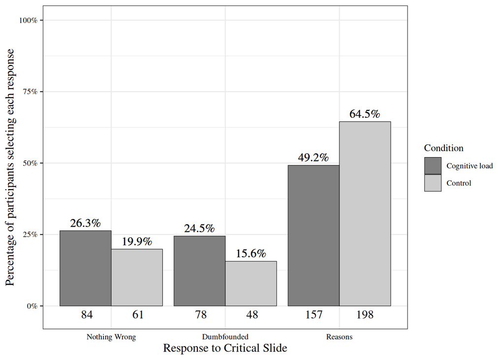

```r
ggplot(test, aes(x=InCS, y=perc, fill=factor(condition,labels=c("Cognitive load","Control")))) +
  scale_y_continuous(limits = c(-.03,1),
                     labels = percent_format()
  )+
  geom_col(position = "dodge",
           color="black",
           size=.2
  )+
  geom_text(family = "Times", size=4.2,
            aes( label = scales::percent(test$perc),
                 y= perc ),
            stat= "identity",
            vjust = -.5,
            position = position_dodge(.9),
            fontface='plain'
            )+
  geom_text(family = "Times", size=4.2,
            aes(label = format(Freq),
                y= -3*(..count../100)/(..count..)),
            stat= "count",
            position = position_dodge(0.9),
            #vjust = -.05,
            fontface='plain'
            ) +
  xlab("Response to Critical Slide") +
  ylab("Percentage of participants selecting each response")+
  scale_x_discrete(labels=c("Nothing Wrong", "Dumbfounded","Reasons")) +
  scale_fill_grey(start = .5, end = .8) +
  labs(fill="Condition") +

  geom_text(family = "Times", size=4.2,
            aes( label = scales::percent(test$perc),
                 y= test$perc ),
            stat= "identity",
            vjust = -.5,
            position = position_dodge(.9),
            fontface='plain'
            )+
  #theme_apa() +
  theme_bw() +
  theme(plot.title=element_text(family="Times",
                                size=12
                                ),
        legend.text=element_text(family="Times",
                                 size=8
                                 ),
          legend.title=element_text(family="Times",
                                    size=10
                                    ),
          axis.text=element_text(family="Times",
                                 colour = "black",
                                 size=8
                                 ),
          axis.ticks.x = element_blank(),
          axis.title=element_text(family="Times",
                                  size=12
                                  ),
          strip.text=element_text(family = "Times",
                                  size = 12
                                  ),
          strip.background = element_rect(fill = "white"),
          legend.position="right")
```

```r
#rm(a,b,c)
#
# g <- ggplot(df3, aes(x=InCS, fill=factor(condition,labels=c("Cognitive load","Control"))))
# g <- g + geom_bar(aes(y=..count..), position = position_dodge(), color="black")
# g <- g + xlab("Response to critical slide")
# #g <- g + ggtitle("Dumbfounding and Cognitive load")
# g <- g + scale_x_discrete(labels=c("nothing wrong", "no reason", "valid reason"))
# g <- g + scale_fill_grey(start = .5, end = .8)+ theme_bw()
# g <- g + labs(fill="Condition")
# #grid.gedit("GRID.text",gp=gpar(fontfamily="serif"))
# g <- g + geom_text(family = "Times", aes(label = format(..count..),y= ..count.. ), stat= "count", vjust = 1.6, position = position_dodge(0.9))
#
# g + theme(plot.title=element_text(family="Times", size=12), legend.text=element_text(family="Times", size=8), legend.title=element_text(family="Times", size=12), axis.text=element_text(family="Times", size=8), axis.title=element_text(family="Times", size=12))
# rm(g)
```

```r
make4graph <- function(){

  tb_count_perc <- function(x){
  tc <- table(x$InCS,x$condition)
  cbind(tc[,1],((tc[,1]/sum(x$condition=="cog_load"))),
        tc[,2],((tc[,2]/sum(x$condition=="control"))))
  }

  tb_count_perc_eng <- function(x){
  tc <- table(x$InCS,x$engaged)
  cbind(tc[,1],((tc[,1]/sum(x$engaged=="engaged"))),
        tc[,2],((tc[,2]/sum(x$engaged=="not engaged"))))
  }


  one$study <- rep("one",length(one$gender))
  one_e <- cbind.data.frame(one$engaged, one$InCS, one$cog_load_CS_num, one$NFC, one$reason_always, one$changed,one$gender, one$Ju1_bin, one$Ju2_bin,one$right_change, one$study)
colnames(one_e) <- c("condition","InCS","cog_load_CS_num","NFC","reason_always","changed","gender","Ju1_bin","Ju2_bin","right_change","study")
  one_e$condition <- car::recode(one_e$condition, "'engaged'='cog_load';'not engaged'='control'")
  eng_0123a <- rbind(engaged0_2_3a,one_e,df5)
  eng_0123b <- rbind(engaged0_2_3b,one_e,df5)

  rows <- c("Nothing wrong","Dumbfounded","Reasons")

  t0 <- tb_count_perc(college)
  t1 <- tb_count_perc_eng(one)
  df3 <- two
  df3 <- df3[which(df3$engaged==TRUE),]
  t2 <- tb_count_perc(df3)
  df3 <- three
  df3 <- df3[which(df3$engaged==TRUE),]
  t3 <- tb_count_perc(df3)
  t5 <- tb_count_perc(study5)
  t0123a <- tb_count_perc(eng_0123a)
  t0123b <- tb_count_perc(eng_0123b)
  t023 <- tb_count_perc(zero_two_three)
  t0123 <- tb_count_perc(zero_one_two_three)



  rbind(t0,t1,t2,t3,t5,t0123a,t0123b)

  rows_left <- c("Study 1"," "," ",
                 "Study 2"," "," ",
                 "Study 3"," "," ",
                 "Study 4"," "," ",
                 "Study 5"," "," ",
                 "Studies 3 and 4"," "," ",
                 "Studies 3 and 4 engaged 1"," "," ",
                 "Studies 3 and 4 engaged 2"," "," ",
                 "Studies 1, 3, and 4"," "," ",
                 "Studies 1, 2, 3, and 4"," "," ")


  test1 <- cbind(c("1Study 6","1Study 6","1Study 6",
                 "2Study 7","2Study 7","2Study 7",
                 "3Study 8","3Study 8","3Study 8",
                 "4Study 9","4Study 9","4Study 9",
                 "5Study 5","5Study 5","5Study 5",
                 "6All studies engaged 1","6All studies engaged 1","6All studies engaged 1",
                 "7All studies engaged 2","7All studies engaged 2","7All studies engaged 2"),
                 rows,
                     unname(rbind(t0,t1,t2,t3,t5,t0123a,t0123b)))

  cols <- c("Study","Response","N","percent","N","percent")
  test1 <- `colnames<-`(test1, cols)

  test1

  test1 <- as.data.frame(test1)
  test1 <- test1[which(test1$Response=="Reasons"),]

  c((test1[3]),(test1[5]))

  c(rep("cog_load",length=6),rep("control",length=6))

  test1 <- cbind(rbind(test1[1:2],test1[1:2]),
                 rbind(test1[3:4],test1[5:6]),
                 c(rep("cog_load",length=7),rep("control",length=7)))

  colnames(test1) <- c("Study","Response","N","percent","condition")
  test1$N <- as.numeric(as.character(test1$N))
  test1$percent <- as.numeric(as.character(test1$percent))
  test1

}
test <- make4graph()
rm(make4graph)
```

```r
#### dumbfounded for graph all ####
make4graph <- function(){

  tb_count_perc <- function(x){
  tc <- table(x$InCS,x$condition)
  cbind(tc[,1],((tc[,1]/sum(x$condition=="cog_load"))),
        tc[,2],((tc[,2]/sum(x$condition=="control"))))
  }

  tb_count_perc_eng <- function(x){
  tc <- table(x$InCS,x$engaged)
  cbind(tc[,1],((tc[,1]/sum(x$engaged=="engaged"))),
        tc[,2],((tc[,2]/sum(x$engaged=="not engaged"))))
  }



  one_e <- cbind.data.frame(one$engaged, one$InCS, one$cog_load_CS_num, one$NFC, one$reason_always, one$changed,one$gender, one$Ju1_bin, one$Ju2_bin,one$right_change)
colnames(one_e) <- c("condition","InCS","cog_load_CS_num","NFC","reason_always","changed","gender","Ju1_bin","Ju2_bin","right_change")
  one_e$condition <- car::recode(one_e$condition, "'engaged'='cog_load';'not engaged'='control'")
  eng_0123a <- rbind(engaged0_2_3a,one_e,df5)
  eng_0123b <- rbind(engaged0_2_3b,one_e,df5)

  rows <- c("Nothing wrong","Dumbfounded","Reasons")

  t0 <- tb_count_perc(college)
  t1 <- tb_count_perc_eng(one)
  df3 <- two
  df3 <- df3[which(df3$engaged==TRUE),]
  t2 <- tb_count_perc(df3)
  df3 <- three
  df3 <- df3[which(df3$engaged==TRUE),]
  t3 <- tb_count_perc(df3)
  t0123a <- tb_count_perc(eng_0123a)
  t0123b <- tb_count_perc(eng_0123b)
  t023 <- tb_count_perc(zero_two_three)
  t0123 <- tb_count_perc(zero_one_two_three)



  rbind(t0,t1,t2,t3,t0123a,t0123b)

  rows_left <- c("Study 6"," "," ",
                 "Study 7"," "," ",
                 "Study 8"," "," ",
                 "Study 9"," "," ",
                 "Studies 8 and 9"," "," ",
                 "Studies 8 and 9 engaged 1"," "," ",
                 "Studies 8 and 9 engaged 2"," "," ",
                 "Studies 6, 8, and 9"," "," ",
                 "Studies 6, 7, 8, and 9"," "," ")


  test1 <- cbind(c("1Study 6","1Study 6","1Study 6",
                 "2Study 7","2Study 7","2Study 7",
                 "3Study 8","3Study 8","3Study 8",
                 "4Study 9","4Study 9","4Study 9",
                 "5All studies engaged 1","5All studies engaged 1","5All studies engaged 1",
                 "6All studies engaged 2","6All studies engaged 2","6All studies engaged 2"),
                 rows,
                     unname(rbind(t0,t1,t2,t3,t0123a,t0123b)))

  cols <- c("Study","Response","N","percent","N","percent")
  test1 <- `colnames<-`(test1, cols)

  test1

  test1 <- as.data.frame(test1)
  test1 <- test1[which(test1$Response=="Dumbfounded"),]

  c((test1[3]),(test1[5]))

  c(rep("cog_load",length=6),rep("control",length=6))

  test1 <- cbind(rbind(test1[1:2],test1[1:2]),
                 rbind(test1[3:4],test1[5:6]),
                 c(rep("cog_load",length=6),rep("control",length=6)))

  colnames(test1) <- c("Study","Response","N","percent","condition")
  test1$N <- as.numeric(as.character(test1$N))
  test1$percent <- as.numeric(as.character(test1$percent))
  test1

}

#test <- make4graph()
rm(make4graph)
```

```r
make4graph <- function(){

  tb_count_perc <- function(x){
  tc <- table(x$InCS,x$condition)
  cbind(tc[,1],((tc[,1]/sum(x$condition=="cog_load"))),
        tc[,2],((tc[,2]/sum(x$condition=="control"))))
  }

  tb_count_perc_eng <- function(x){
  tc <- table(x$InCS,x$engaged)
  cbind(tc[,1],((tc[,1]/sum(x$engaged=="engaged"))),
        tc[,2],((tc[,2]/sum(x$engaged=="not engaged"))))
  }


  one$study <- rep("on2",length(one$gender))
  one_e <- cbind.data.frame(one$engaged, one$InCS, one$cog_load_CS_num, one$NFC, one$reason_always, one$changed,one$gender, one$Ju1_bin, one$Ju2_bin,one$right_change,one$study)
colnames(one_e) <- c("condition","InCS","cog_load_CS_num","NFC","reason_always","changed","gender","Ju1_bin","Ju2_bin","right_change","study")
  one_e$condition <- car::recode(one_e$condition, "'engaged'='cog_load';'not engaged'='control'")
  eng_0123a <- rbind(engaged0_2_3a,one_e,df5)
  eng_0123b <- rbind(engaged0_2_3b,one_e,df5)

  rows <- c("Nothing wrong","Dumbfounded","Reasons")

  t0 <- tb_count_perc(college)
  t1 <- tb_count_perc_eng(one)
  df3 <- two
  df3 <- df3[which(df3$engaged==TRUE),]
  t2 <- tb_count_perc(df3)
  df3 <- three
  df3 <- df3[which(df3$engaged==TRUE),]
  t3 <- tb_count_perc(df3)
  t5 <- tb_count_perc(study5)
  t0123a <- tb_count_perc(eng_0123a)
  t0123b <- tb_count_perc(eng_0123b)
  t023 <- tb_count_perc(zero_two_three)
  t0123 <- tb_count_perc(zero_one_two_three)



  rbind(t0,t1,t2,t3,t5,t0123a,t0123b)

  rows_left <- c("Study 1"," "," "
                 ,"Study 2"," "," "
                 ,"Study 3"," "," "
                 ,"Study 4"," "," "
                 ,"Study 5"," "," "
                 ,"Studies 3 and 4"," "," "
                 ,"Studies 3 and 4 engaged 1"," "," "
                 ,"Studies 3 and 4 engaged 2"," "," "
                 ,"Studies 1, 3, and 4"," "," "
                 ,"Studies 1, 2, 3, and 4"," "," "
                 )


  test1 <- cbind(c("1Study 6","1Study 6","1Study 6"
                   ,"2Study 7","2Study 7","2Study 7"
                   ,"3Study 8","3Study 8","3Study 8"
                   ,"4Study 9","4Study 9","4Study 9"
                   ,"5Study 5","5Study 5","5Study 5"
                   #,"6All studies engaged 1","6All studies engaged 1","6All studies engaged 1"
                   #,"7All studies engaged 2","7All studies engaged 2","7All studies engaged 2"
                   ),
                 rows,
                     unname(rbind(
                       t0
                       ,t1
                       ,t2
                       ,t3
                       ,t5
                       #,t0123a
                       #,t0123b
                       )))

  cols <- c("Study","Response","N","percent","N","percent")
  test1 <- `colnames<-`(test1, cols)

  test1

  test1 <- as.data.frame(test1)
  test1 <- test1[which(test1$Response=="Reasons"),]

  c((test1[3]),(test1[5]))

  c(rep("cog_load",length=6),rep("control",length=6))

  test1 <- cbind(rbind(test1[1:2],test1[1:2]),
                 rbind(test1[3:4],test1[5:6]),
                 c(rep("cog_load",length=5),rep("control",length=5)))

  colnames(test1) <- c("Study","Response","N","percent","condition")
  test1$N <- as.numeric(as.character(test1$N))
  test1$percent <- as.numeric(as.character(test1$percent))
  test1

}
test <- make4graph()
rm(make4graph)
```